# HW4

2023-02-21

```r
library(vegan)
data(dune)
data(dune.env)
?dune
```

Question 1: Conduct an indirect ordination on the dune plant community. Specifically, visually examine a NMDS plot using the bray-curtis distance metric. Below is some code to help you develop a potential plot that emphasizes the role of the environmental variable “Moisture”. Describe how you interpret the graphic. What is the goal of creating such a plot? Does this analysis suggest any interesting findings with respect to the dune vegetation?

```r
set.seed(123)
dune_mds <- metaMDS(dune, distance = "bray")
```

```
## *** Best solution repeated 3 times
```

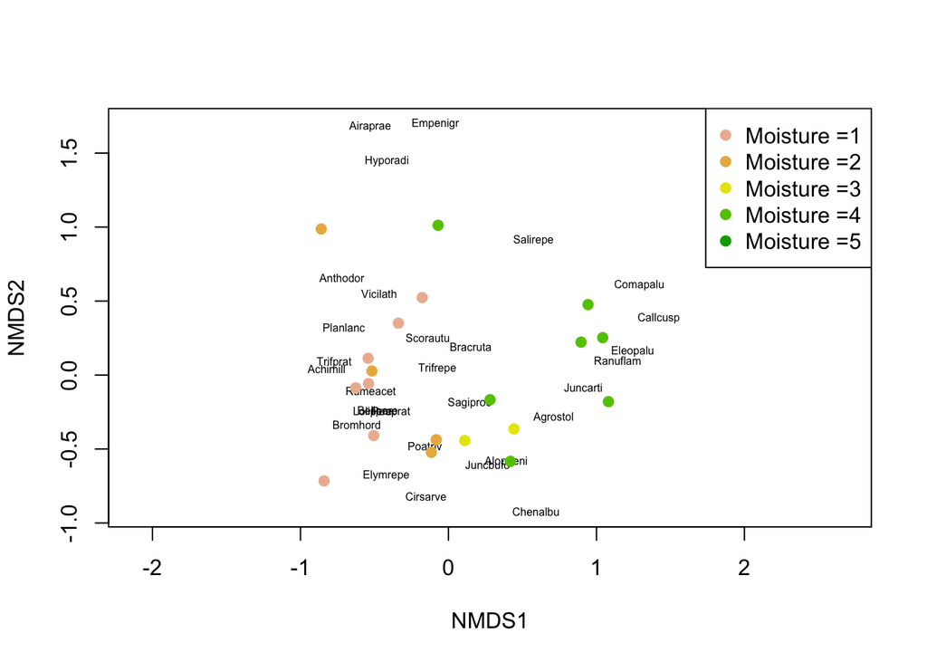

```r
plot(dune_mds, type='n')
 text(dune_mds, 'sp', cex=.5)
 # generate vector of colors
 color_vect = rev(terrain.colors(6))[-1]
 points(dune_mds, 'sites', pch=19,
        col=color_vect[dune.env$Moisture])
 legend('topright', paste("Moisture =", 1:5, sep=''),
        col=color_vect, pch=19)
```

#’ This plot helps visualize the similarity between plant communities based on the Bray-Curtis distance metric (which measures the dissimilarity in species composition). Meaning samples that are closer together are more similar in species composition than samples that are farther apart. The points show the moisture level of each sample (moisture levels according to color key). According to this, there is a clear moisture gradient (i.e., relationship between moisture and the distribution of dune plants).

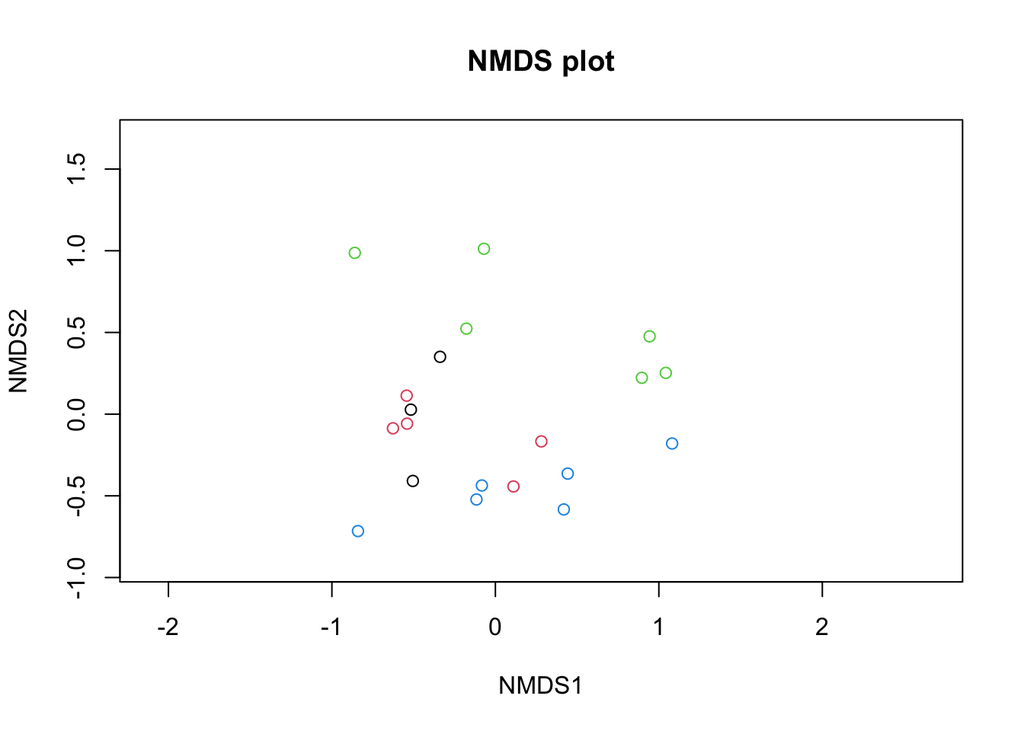

```r
ordiplot(dune_mds, type = "n", main = "NMDS plot")
points(dune_mds, display = "sites", col = dune.env$Management)
```

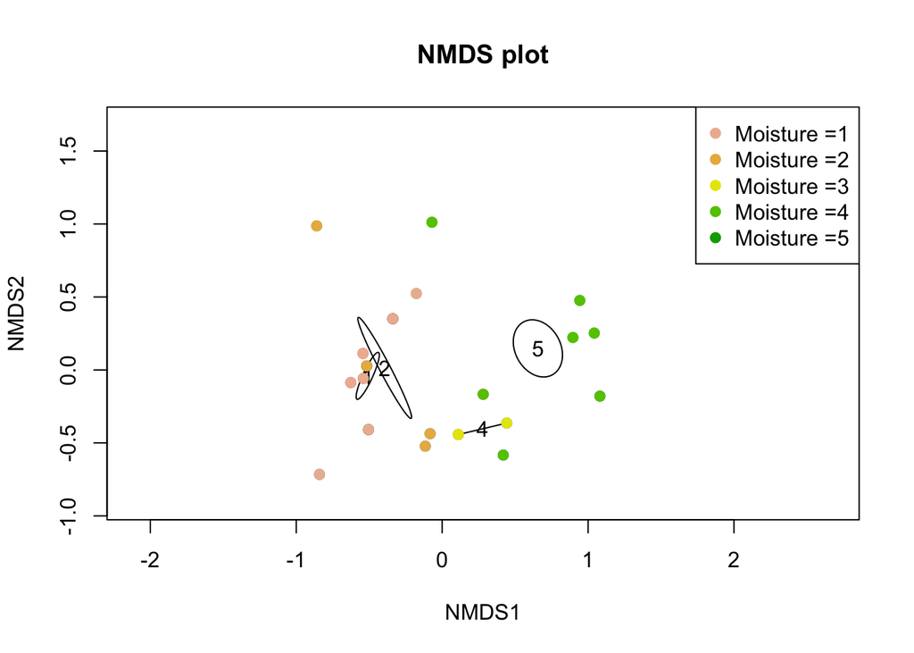

```r
ordiplot(dune_mds, type = "n", main = "NMDS plot")
points(dune_mds, display = "sites", col = dune.env$Management)
ordiellipse(dune_mds, groups = dune.env$Moisture, kind = "se", label = TRUE)
 # generate vector of colors
 color_vect = rev(terrain.colors(6))[-1]
 points(dune_mds, 'sites', pch=19,
        col=color_vect[dune.env$Moisture])
 legend('topright', paste("Moisture =", 1:5, sep=''),
        col=color_vect, pch=19)
```

```r
dune_pca <- rda(dune)
dune_pca
```

```
## Call: rda(X = dune)
##
##               Inertia Rank
## Total           84.12
## Unconstrained   84.12   19
## Inertia is variance
##
## Eigenvalues for unconstrained axes:
##    PC1    PC2    PC3    PC4    PC5    PC6    PC7    PC8
## 24.795 18.147  7.629  7.153  5.695  4.333  3.199  2.782
## (Showing 8 of 19 unconstrained eigenvalues)
```

```r
str(dune_pca)
```

```
## List of 10
##  $ colsum        : Named num [1:30] 1.24 2.683 0.786 2.628 1.701 ...
##   ..- attr(*, "names")= chr [1:30] "Achimill" "Agrostol" "Airaprae" "Alopgeni" ...
##  $ tot.chi       : num 84.1
##  $ Ybar          : num [1:20, 1:30] 0.0459 0.5047 -0.1835 -0.1835 0.2753 ...
##   ..- attr(*, "scaled:center")= Named num [1:30] 0.8 2.4 0.25 1.8 1.05 0.65 0.75 0.05 0.1 0.2 ...
##   .. ..- attr(*, "names")= chr [1:30] "Achimill" "Agrostol" "Airaprae" "Alopgeni" ...
##   ..- attr(*, "dimnames")=List of 2
##   .. ..$ : chr [1:20] "1" "2" "3" "4" ...
##   .. ..$ : chr [1:30] "Achimill" "Agrostol" "Airaprae" "Alopgeni" ...
##   ..- attr(*, "METHOD")= chr "PCA"
##  $ method        : chr "rda"
##  $ call          : language rda(X = dune)
##  $ pCCA          : NULL
##  $ CCA           : NULL
##  $ CA            :List of 6
##   ..$ eig    : Named num [1:19] 24.8 18.15 7.63 7.15 5.7 ...
##   .. ..- attr(*, "names")= chr [1:19] "PC1" "PC2" "PC3" "PC4" ...
##   ..$ poseig : NULL
##   ..$ u      : num [1:20, 1:19] -0.1355 -0.26013 -0.0696 0.00758 -0.25691 ...
##   .. ..- attr(*, "dimnames")=List of 2
##   .. .. ..$ : chr [1:20] "1" "2" "3" "4" ...
##   .. .. ..$ : chr [1:19] "PC1" "PC2" "PC3" "PC4" ...
##   ..$ v      : num [1:30, 1:19] -0.17589 0.40025 0.00682 0.15475 -0.16288 ...
##   .. ..- attr(*, "dimnames")=List of 2
##   .. .. ..$ : chr [1:30] "Achimill" "Agrostol" "Airaprae" "Alopgeni" ...
##   .. .. ..$ : chr [1:19] "PC1" "PC2" "PC3" "PC4" ...
##   ..$ rank   : int 19
##   ..$ tot.chi: num 84.1
##  $ inertia       : chr "variance"
##  $ regularization: chr "this is a vegan::rda result object"
##  - attr(*, "class")= chr [1:2] "rda" "cca"
```

```r
dune_pca$tot.chi
```

```
## [1] 84.12368
```

```r
dune_pca$CA$eig
```

```
##        PC1        PC2        PC3        PC4        PC5        PC6        PC7
## 24.7953194 18.1466207  7.6291349  7.1527720  5.6950268  4.3333065  3.1993646
##        PC8        PC9       PC10       PC11       PC12       PC13       PC14
##  2.7818646  2.4819845  1.8537672  1.7471173  1.3135832  0.9905115  0.6377937
##       PC15       PC16       PC17       PC18       PC19
##  0.5508266  0.3505841  0.1995562  0.1487978  0.1157526
```

```r
sum(dune_pca$CA$eig)
```

```
## [1] 84.12368
```

```r
# verify that this is equal to the sum of the variances (i.e., diagonal elements) in the species covariance matrix
sum(diag(cov(dune)))
```

```
## [1] 84.12368
```

```r
cen_dune <- apply(dune, 2, function(x) x - mean(x))
cov_dune <- nrow(dune)^-1 * t(cen_dune) %*% cen_dune
sum(diag(cov_dune))
```

```
## [1] 79.9175
```

```r
round(dune_pca$CA$eig / dune_pca$tot.chi, 2)
```

```
##  PC1  PC2  PC3  PC4  PC5  PC6  PC7  PC8  PC9 PC10 PC11 PC12 PC13 PC14 PC15 PC16
## 0.29 0.22 0.09 0.09 0.07 0.05 0.04 0.03 0.03 0.02 0.02 0.02 0.01 0.01 0.01 0.00
## PC17 PC18 PC19
## 0.00 0.00 0.00
```

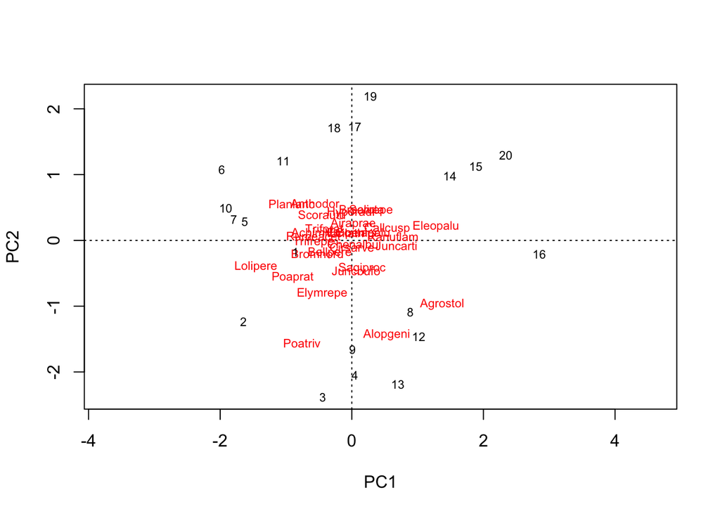

```r
plot(dune_pca)
```

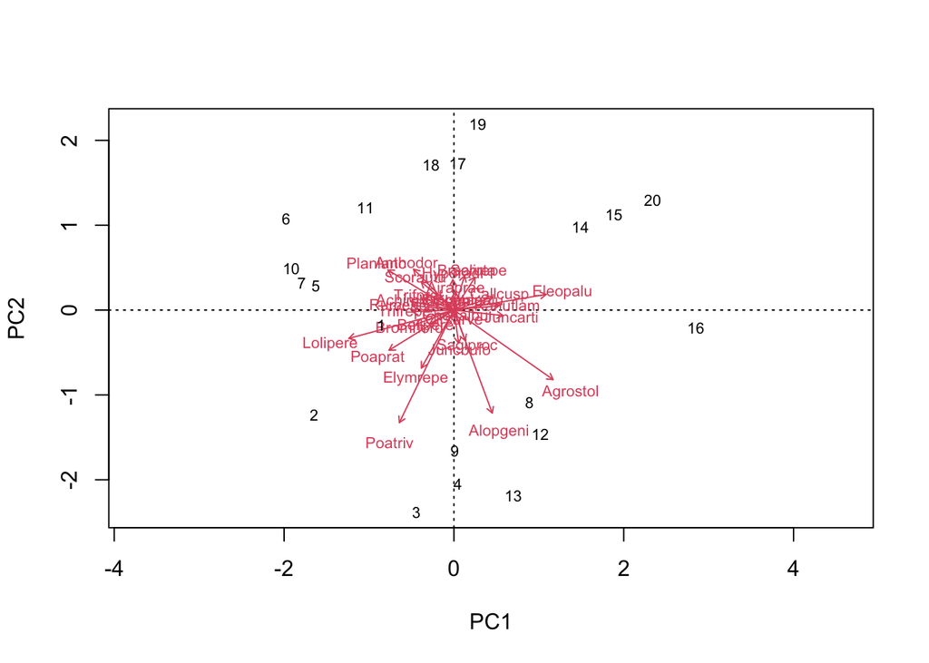

```r
biplot(dune_pca)
```

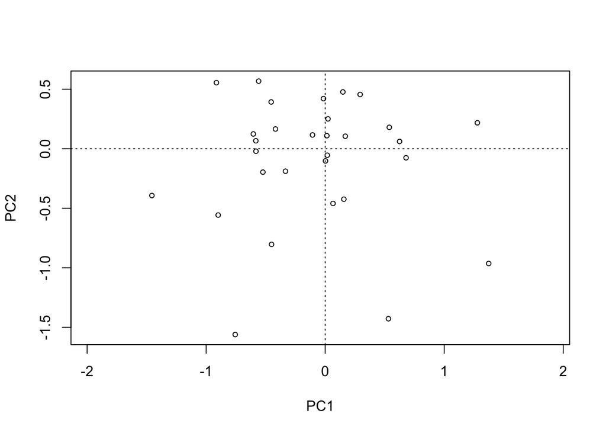

```r
ordiplot(dune_pca, display = 'sp')
```

```r
dune_ca <- cca(dune)
dune_ca
```

```
## Call: cca(X = dune)
##
##               Inertia Rank
## Total           2.115
## Unconstrained   2.115   19
## Inertia is scaled Chi-square
##
## Eigenvalues for unconstrained axes:
##    CA1    CA2    CA3    CA4    CA5    CA6    CA7    CA8
## 0.5360 0.4001 0.2598 0.1760 0.1448 0.1079 0.0925 0.0809
## (Showing 8 of 19 unconstrained eigenvalues)
```

Question 2: Carry out a direct ordination using CCA in order to test any potential hypotheses that you developed after examining the MDS plot. Specifically, carry out a test of the entire model (i.e., including all constrained axes) and also carry out tests at the scale of individual explanatory variables you included in your model if you included more than one variable. Plot your results.

```r
cca_dune <- cca(dune ~ ., data=dune.env)
RsquareAdj(cca_dune, 100)
```

```
## $r.squared
## [1] 0.7106267
##
## $adj.r.squared
## [1] 0.2146442
```

```r
anova(cca_dune, permutations = 999)
```

```
## Permutation test for cca under reduced model
## Permutation: free
## Number of permutations: 999
##
## Model: cca(formula = dune ~ A1 + Moisture + Management + Use + Manure, data = dune.env)
##          Df ChiSquare      F Pr(>F)
## Model    12    1.5032 1.4325  0.027 *
## Residual  7    0.6121
## ---
## Signif. codes:  0 '***' 0.001 '**' 0.01 '*' 0.05 '.' 0.1 ' ' 1
```

```r
anova(cca_dune, by='margin', permutations = 999)
```

```
## Permutation test for cca under reduced model
## Marginal effects of terms
## Permutation: free
## Number of permutations: 999
##
## Model: cca(formula = dune ~ A1 + Moisture + Management + Use + Manure, data = dune.env)
##            Df ChiSquare      F Pr(>F)
## A1          1   0.11070 1.2660  0.243
## Moisture    3   0.31587 1.2041  0.232
## Management  2   0.15882 0.9081  0.578
## Use         2   0.13010 0.7439  0.785
## Manure      3   0.25490 0.9717  0.520
## Residual    7   0.61210
```

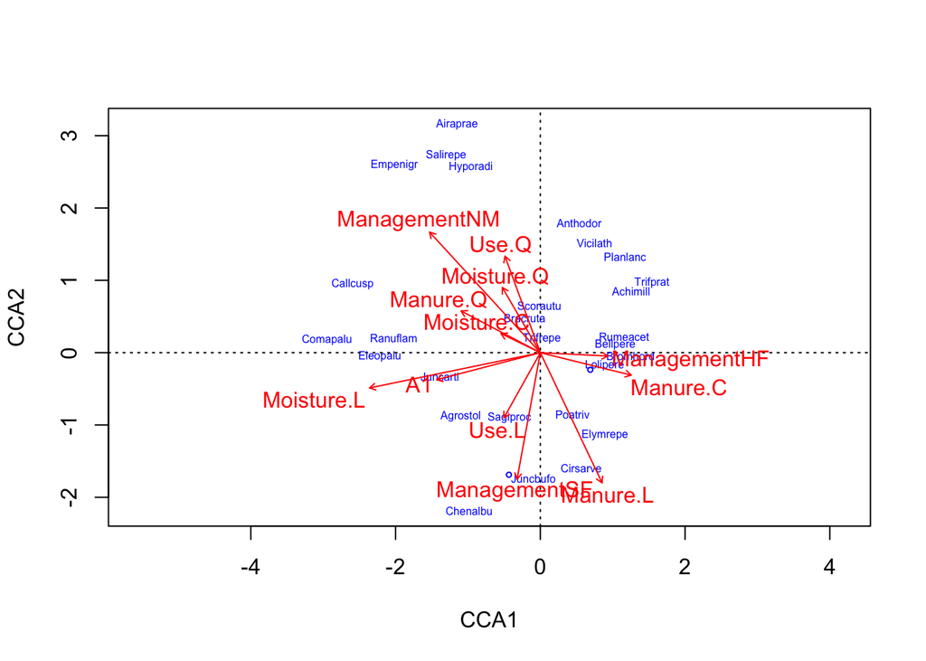

```r
plot(cca_dune, type='n', scaling=1)
orditorp(cca_dune, display='sp', cex=0.5, scaling=1, col='blue')
text(cca_dune, display='bp', col='red')
```

```r
# Fit CCA using formula interface
dune.cca <- cca(dune ~ ., data = dune.env)

# Perform CCA with individual variables
dune.cca.Moisture <- cca(dune, dune.env$Moisture)
dune.cca.A1 <- cca(dune, dune.env$A1)

anova(dune.cca, by="axis", step=2)
```

```
## Permutation test for cca under reduced model
## Forward tests for axes
## Permutation: free
## Number of permutations: 999
##
## Model: cca(formula = dune ~ A1 + Moisture + Management + Use + Manure, data = dune.env)
##          Df ChiSquare      F Pr(>F)
## CCA1      1   0.46713 5.3422  0.028 *
## CCA2      1   0.34102 3.8999  0.296
## CCA3      1   0.17606 2.0135  0.906
## CCA4      1   0.15317 1.7516  0.955
## CCA5      1   0.09528 1.0896  0.998
## CCA6      1   0.07027 0.8036  1.000
## CCA7      1   0.05887 0.6732  1.000
## CCA8      1   0.04993 0.5710  1.000
## CCA9      1   0.03183 0.3640  1.000
## CCA10     1   0.02596 0.2969  0.999
## CCA11     1   0.02282 0.2610  0.999
## CCA12     1   0.01082 0.1237  0.995
## Residual  7   0.61210
## ---
## Signif. codes:  0 '***' 0.001 '**' 0.01 '*' 0.05 '.' 0.1 ' ' 1
```

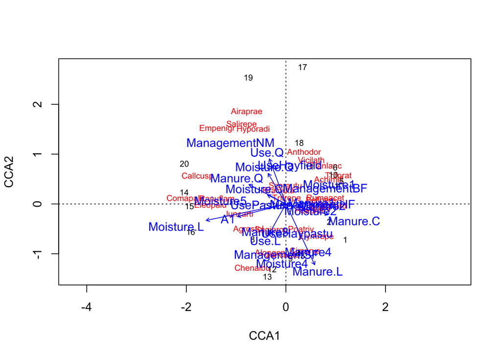

```r
plot(dune.cca)
```

#’ Overall, CCA can help us test the relationships between the environmental variables and the species in the dune dataset, and can provide insight into which variables are most important for explaining the distribution and abundance of species. By examining the significance of individual axes and creating biplots, we can gain a better understanding of the relationships between variables (Moisture, Management and Maure, etc.) and species in the dataset. Even though the p-value for Moisture is not extremely signicant, compared to the other variables in the CCA analysis.

Question 3: Do your two analyses agree with one another or complement one another or do these two analyses seem to be suggesting different take home messages? Which analysis do you find to be more useful?